# 28_sesonal_ARIMA_toBeCorrected

```r
library(astsa)
library(fpp3)
library(patchwork)
```

# References:

1. Forecasting Principles and Practice - 3rd Edition (Rob J Hyndman and George Athanasopoulos) [Link](https://otexts.com/fpp3/)
2. Time Series: a data analysis approach using R - Shumwway-Stoffer - This book is a distilled version of reference 3. Still math intensive, yet much less challenging than reference 3. [Link](https://ie.on.worldcat.org/oclc/1101967011)
3. Time-Series Analysis and its Applications with R Examples - Shumway-Stoffer
4. Time Series Analysis: Forecasting and Control - 5th Edition - George E. P. Box, Gwilym M. Jenkins, Gregory C. Reinsel, Greta M. Ljung - this book is a very complete guide to ARIMA models. Yet very long.

(TODO: write references formally)

# NOTE

This notebook is not original material but rather somewhat of an extension with further explanations to reference 1.

# Seasonal ARIMA

The SARIMA models, or ARIMA$(p,d,q)(P,D,Q)_m$, an enhancement of ARIMA models to handle time series with seasonality.

$$\begin{equation}
\begin{array}{c c}
(p, d, q) & (P, D, Q)_m\\
{\uparrow} & {\uparrow}\\
\text{Non-seasonal} & \text{Seasonal}\\
\end{array}
\end{equation}$$

where:

- $m$ is the length of the seasonal period (the number of observations in one year).
- $d$ is the number of lag-1 differences
- $p$ is the number of ordinary AR lags ($x_{t-1}, x_{t-2}, ..., x_{t-p}$)
- $q$ is the number of ordinary MA lags ($w_{t-1}, w_{t-2}, ..., w_{t-q}$)
- $D$ is the number of seasonal differences
- $P$ is the number of seasonal AR lags: ($x_{t-m}, x_{t-2m}, ..., x_{t-Pm}$)
- $Q$ is the number of seasonal MA lags: ($w_{t-m}, w_{t-2m}, ..., w_{t-Qm}$)

The seasona part of the model consists of terms that are similar to the non-seasonal cimponents of the model, but involve backshifts of the seasonal period.

The model combines the seasonal and non-seasonal parts of the model in a multiplicative manner. The resulting model can thefefore be quite complex to write down and is **non-linear**. In terms of the **backshift operator** the model looks as follows:

$$\begin{equation}
\begin{array}{c c c c c c}
(1-\phi_1B - \cdots - \phi_p B^p) & (1-\Phi_1B^m - \cdots - \Phi_p B^{Pm}) & (1-B)^d & (1-B^m)^D x_{t} & = (1 + \theta_1 B + \cdots + \theta_q B^q) & (1 + \Theta_1 B^m + \cdots + \Theta_q B^{Qm})w_t\\
{\uparrow} & {\uparrow} & {\uparrow} & {\uparrow} & {\uparrow} &{\uparrow}\\
\text{AR($p$)} & \text{AR($P$)} & \text{$d$ differences} & \text{$D$ differences} & \text{MA($q$)} & \text{MA($Q$)}\\
\end{array}
\end{equation}$$

Example: an ARIMA $(1,1,1)(1,1,1)_4$ model without a constant for quarterly data ($m=4$) and can be written as:

$$(1 - \phi_{1}B)~(1 - \Phi_{1}B^{4}) (1 - B) (1 - B^{4})y_{t} =
(1 + \theta_{1}B)~ (1 + \Theta_{1}B^{4})\varepsilon_{t}$$
Example: an ARIMA $(2,2,1)(1,2,2)_4$ model with a constant for quarterly data ($m=4$) and can be written as:

$$(1 - \phi_{1}B - \phi_2B^2)~(1 - \Phi_{1}B^{4}) (1 - B)^2 (1 - B^{4})^2y_{t} = c+
(1 + \theta_{1}B)~ (1 + \Theta_{1}B^{4} + \Theta_{2}B^{8})\varepsilon_{t}$$

# ACF and PACF of a Seasonal Arima Model

The PACF and ACF of a purely seasonal model AR or MA model will exhibit spikes in the seasonal lags (lags $m, 2m, 3m\dots$) following the same *cut-off* and *tail-off* logic of non-seasonal models. In this case the associated table to determine the seasonal lags would be:

|  | sAR(P) (Q=0) | sMA(Q) (P=0) | sARMA(P,Q) |
| --- | --- | --- | --- |
| ACF (seasonal lags) | Tails-off | Cuts off after seasonal lag Q | Tails-off |
| PACF (seasonal lags) | Cuts-off after seasonal lag P | Tails off | Tails-off |

In the table above note the fact that we now have $P$ and $Q$ instead of $p$ and $q$ because we are referring to the seasonal part of the ARIMA model. Note as well that now we have sAR instead of AR indicating *seasonal auto-regressive model* and sMA indicating *seasonal moving-average model*.

Regarding the expression *seasonal lag*: * The first seasonal lag would be lag 4 for quarterly data, lag 12 for monthly data, etc… * The second seasonal lag would be lag 8 for quarterly data, lag 24 for monthly data, etc…

**After rendering the data trend-stationary and seasonal-stationary by means of seasonal differences (**$D$) and ordinary differences ($d$), we would print the ACF and PACF of the resulting stationary series and then use the table above to interpret the **seasonal part of the model** looking at the **seasonal lags of the ACF and PACF**.

For the **non-seasonal part of the model** we have to use the table introduced in the session on ARMA models:

|  | AR(p) (q=0) | MA(q) (p=0) | ARMA(p,q) |
| --- | --- | --- | --- |
| ACF (non-seasonal lags) | Tails-off | Cuts off after lag q | Tails-off |
| PACF (non-seasonal lags) | Cuts-off after lag p | Tails off | Tails-off |

All of this is better understood through examples.

## Examples with simulated data (purely seasonal models):

Again we are going to start with simulated data to see how the seasonal lags of the ACF and PACF of purely sMA (seasonal MA) and sAR (seasonal AR) models look like:

### Example: ARIMA$(0,0,0)(1,0,0)_{12}$

```
Plot variable not specified, automatically selected `.vars = value`
```

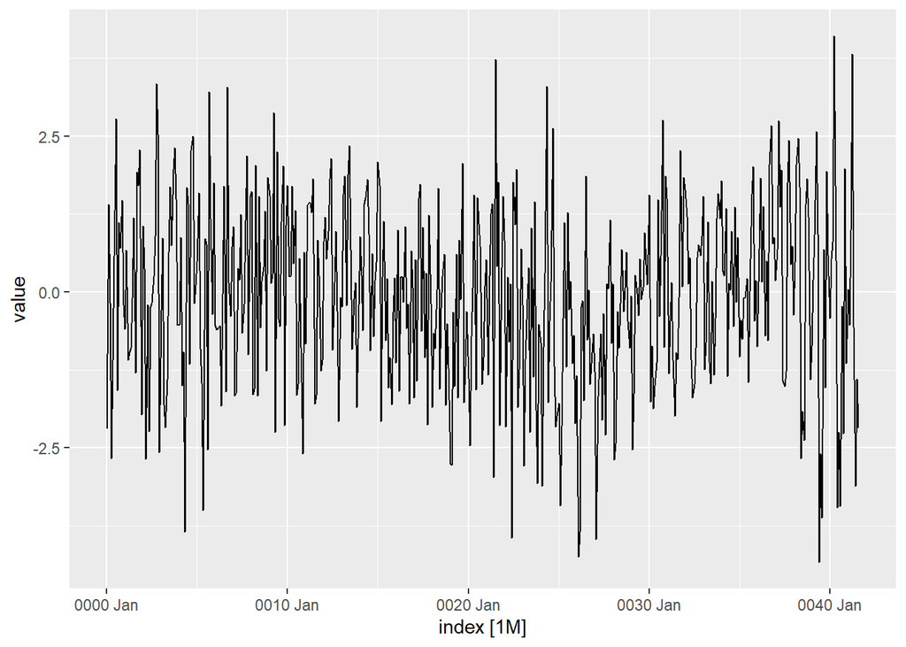

```r
set.seed(1011)
y_sar1 <- sarima.sim(sar=c(0.75), S=12) %>% as_tsibble()
y_sar1 %>% autoplot()
```

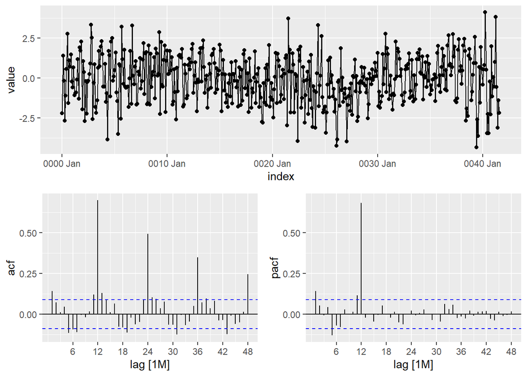

```r
y_sar1 %>%
  gg_tsdisplay(value, plot_type='partial', lag=48)
```

In this case the seasonal lags of the ACF tail off and the seasonal lags of the PACF cut-off after the first seasonal lag (lag 12). Therefore $P=1$ and $Q=0$

### Example: ARIMA$(0,0,0)(2,0,0)_{12}$

```
Plot variable not specified, automatically selected `.vars = value`
```

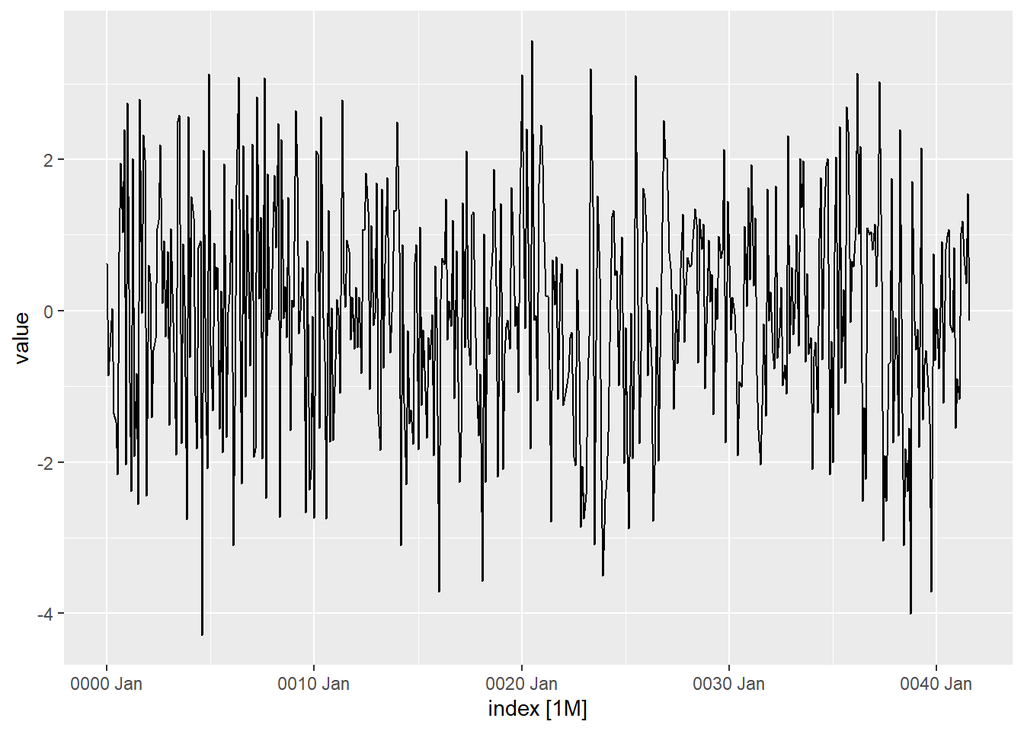

```r
set.seed(1011)
y_sar2 <- sarima.sim(sar=c(0.75, -0.6), S=12) %>% as_tsibble()
y_sar2 %>% autoplot()
```

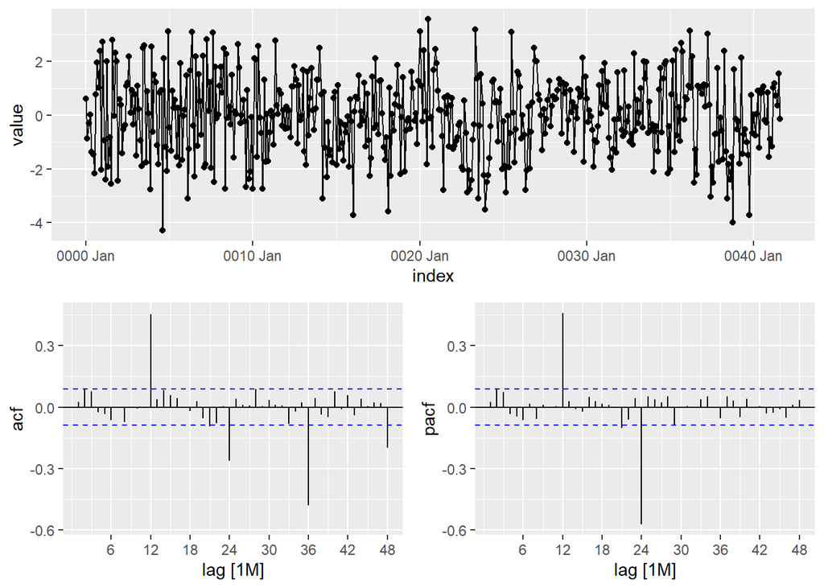

```r
y_sar2 %>%
  gg_tsdisplay(value, plot_type='partial', lag=48)
```

### Example: another ARIMA$(0,0,0)(2,0,0)_{12}$

This example is picked up to show that the resulting ACF and PACF can be confusing

```
Plot variable not specified, automatically selected `.vars = value`
```

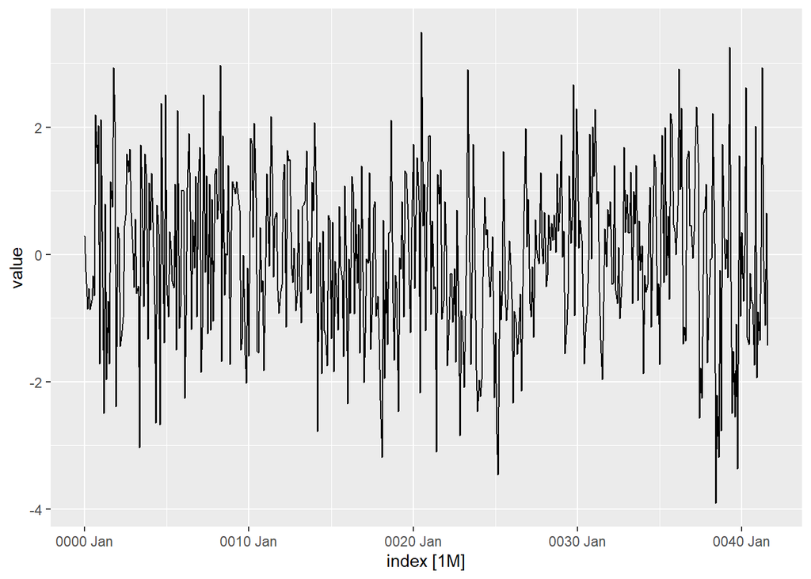

```r
set.seed(1011)
y_sar2_alt <- sarima.sim(sar=c(0.75, -0.25), S=12) %>% as_tsibble()
y_sar2_alt %>% autoplot()
```

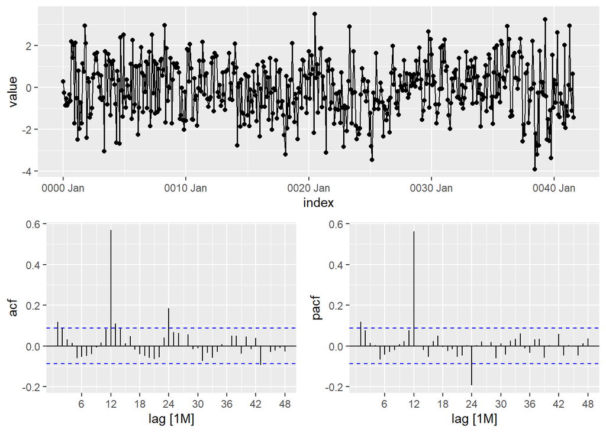

```r
y_sar2_alt %>%
  gg_tsdisplay(value, plot_type='partial', lag=48)
```

In this case if we knew nothing about the data we could perfectly think that both ACF and PACF are cutting-off. We will proceed as indicated in the notebook for ARMA models, that is, we will fit two models:

- **Model 1:** model hinted by the PACF
  - Cut-off of PACF at the second seasonal lag
  - Assumtion that ACF is tailing-off
  - Result: $P=2$ and $Q=0$ (ARIMA(0,0,0)(2,0,0)12)
- **Model 2:** model hinted by the PACF
  - Cut-off of ACF at the second seasonal lag
  - Assumtion that PACF is tailing-off
  - Result: $P=0$ and $Q=2$ (ARIMA(0,0,0)(0,0,2)12)

The example goes to show that even for data that should be quite clean and clear (simulated data), the ACF and PACF can be confusing.

### Example ARIMA$(0,0,0)(0,0,1)_{12}$

```
Plot variable not specified, automatically selected `.vars = value`
```

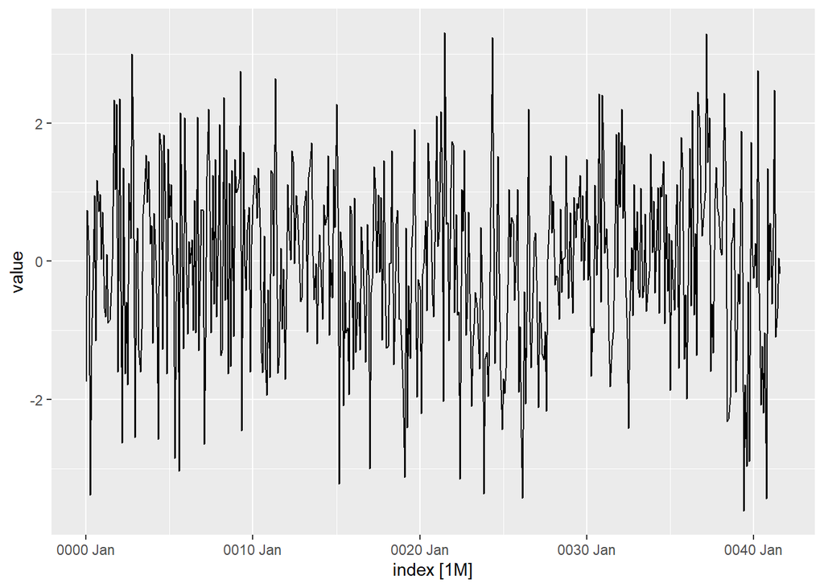

```r
set.seed(1011)
y_sma1 <- sarima.sim(sma=c(0.8), S=12) %>% as_tsibble()
y_sma1 %>% autoplot()
```

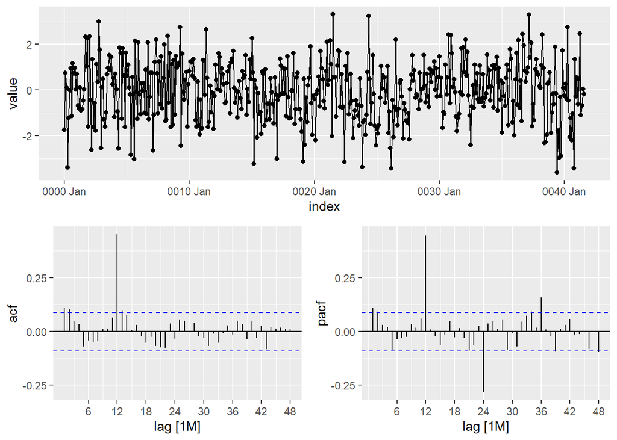

```r
y_sma1 %>%
  gg_tsdisplay(value, plot_type='partial', lag=48)
```

In this case the seasonal lags of the PACF tail off and the seasonal lags of the ACF cut-off after the first seasonal lag (lag 12). Therefore $P=0$ and $Q=1$ (ARIMA(0,0,0)(0,0,1)12)

### Example ARIMA$(0,0,0)(0,0,2)_{12}$

```
Plot variable not specified, automatically selected `.vars = value`
```

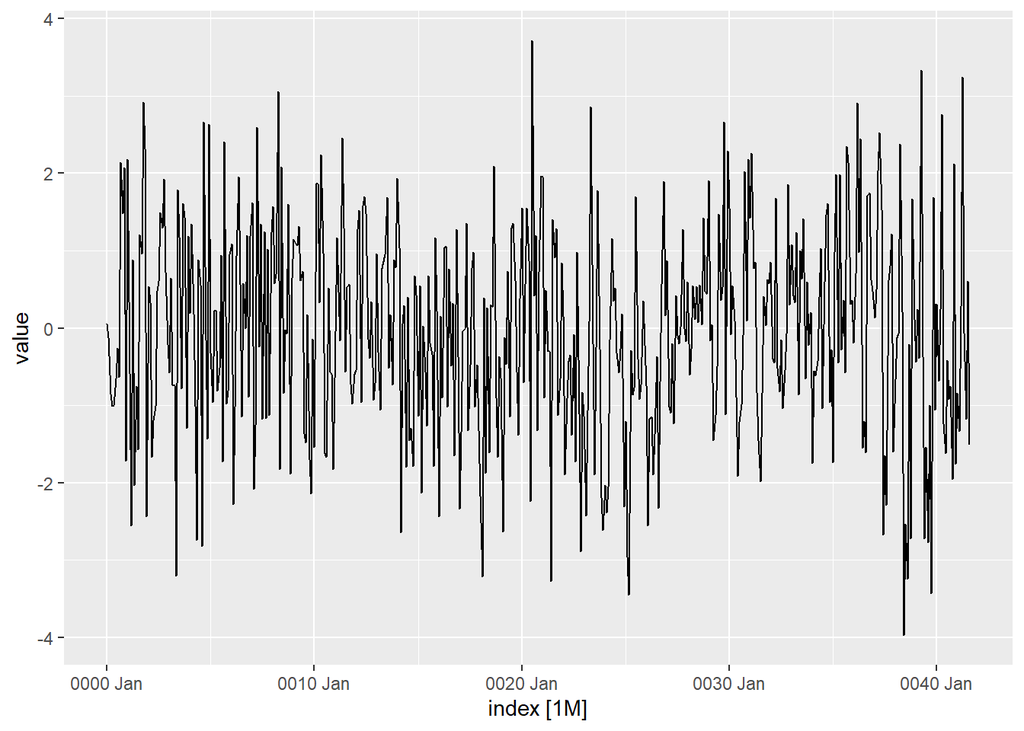

```r
set.seed(1011)
y_sma2 <- sarima.sim(sma=c(0.8, 0.4), S=12) %>% as_tsibble()
y_sma2 %>% autoplot()
```

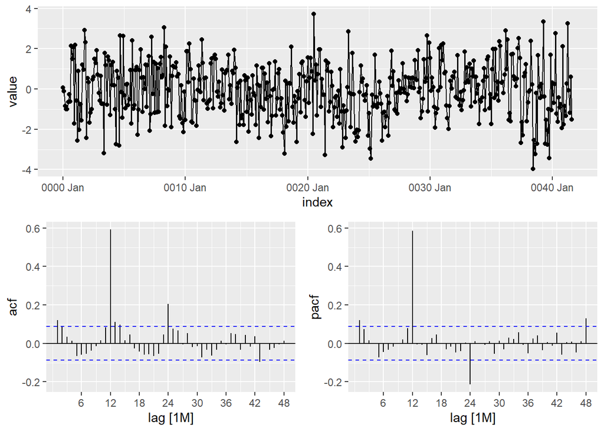

```r
y_sma2 %>%
  gg_tsdisplay(value, plot_type='partial', lag=48)
```

In this case if we knew nothing about the data we could perfectly think that both ACF and PACF are cutting-off. We will proceed as indicated in the notebook for ARMA models, that is, we will fit two models:

- **Model 1:** model hinted by the PACF
  - Cut-off of PACF at the second seasonal lag
  - Assumption that ACF is tailing-off
  - Result: $P=2$ and $Q=0$ (ARIMA(0,0,0)(2,0,0)12)
- **Model 2:** model hinted by the PACF
  - Cut-off of ACF at the second seasonal lag
  - Assumption that PACF is tailing-off
  - Result: $P=0$ and $Q=2$ (ARIMA(0,0,0)(0,0,2)12)

The example goes to show that even for data that should be quite clean and clear (simulated data), the ACF and PACF can be confusing.

## Examples with real data

The important thing when interpreting ACF and PACF now is to separate between the seasonal and the non-seasonal parts of the model.

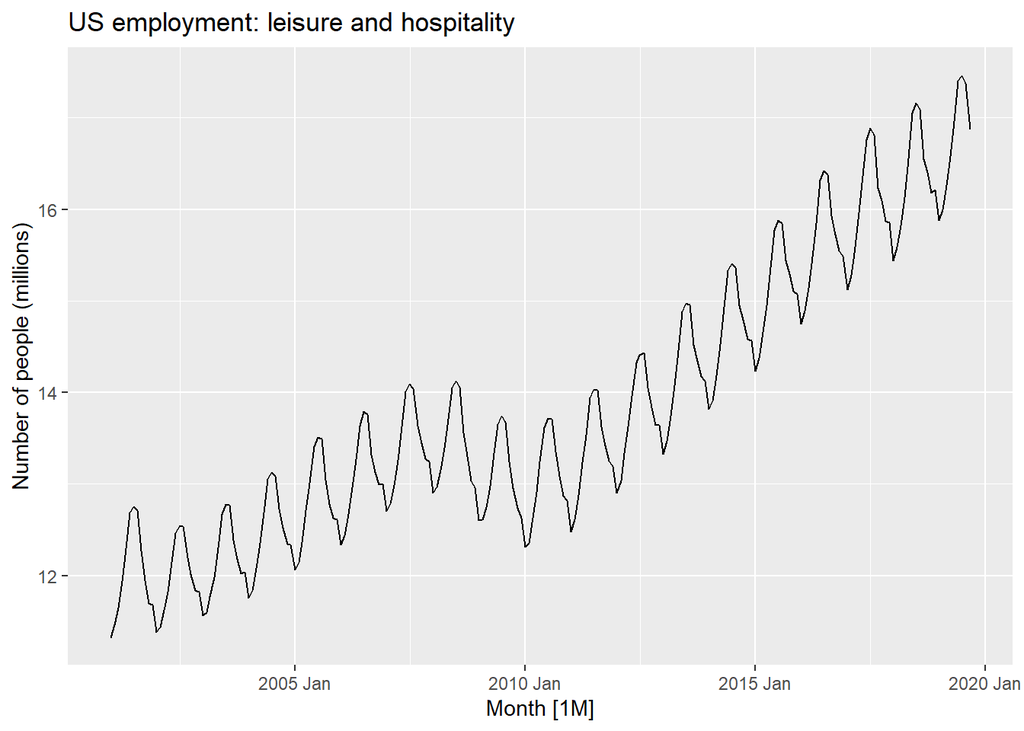

```r
leisure <- us_employment %>%
  filter(Title == "Leisure and Hospitality",
         year(Month) > 2000) %>%
  mutate(
          Employed = Employed/1000,
          # First seasonal difference
          emp_sdiff = difference(Employed, 12),
          # First order difference
          emp_sdiff_diff = difference(emp_sdiff, 1)
         ) %>%
  select(Month, Employed, emp_sdiff, emp_sdiff_diff)

autoplot(leisure, Employed) +
  labs(title = "US employment: leisure and hospitality",
       y="Number of people (millions)")
```

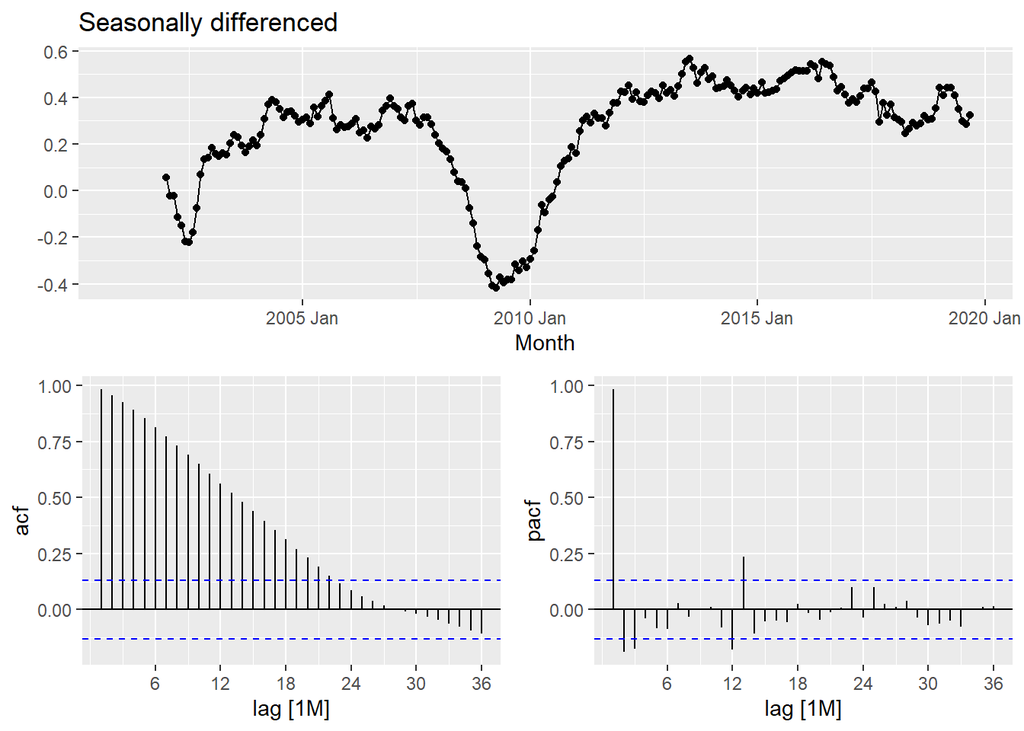

```r
leisure %>%
  gg_tsdisplay(emp_sdiff,
               plot_type='partial', lag=36) +
  labs(title="Seasonally differenced", y="")
```

The ACF of the series after one seasonal lag clearly exhibits non-stationarity in the trend, so we take now first-order differences

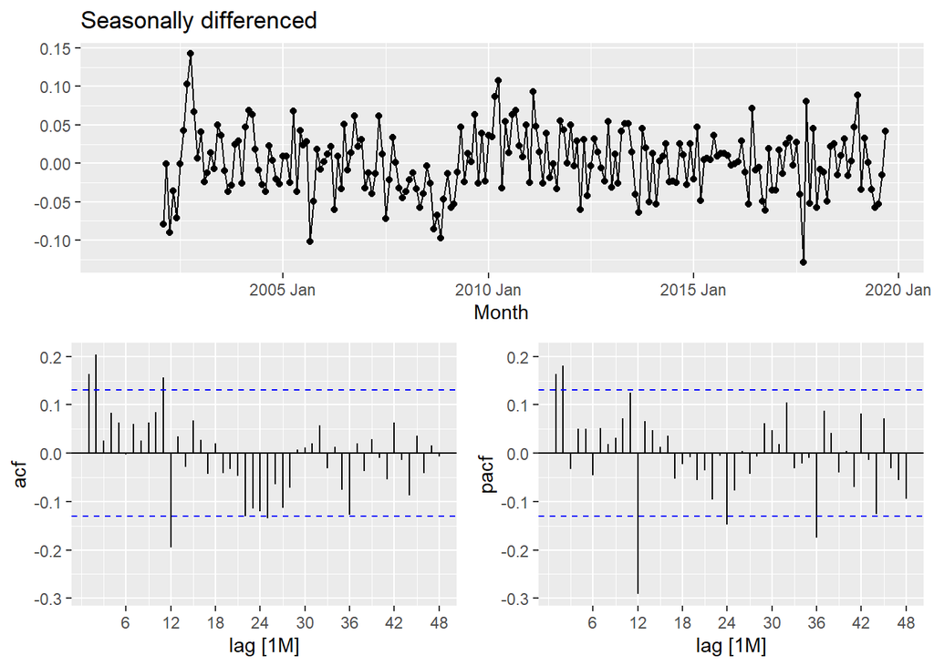

```r
leisure %>%
  gg_tsdisplay(emp_sdiff_diff,
               plot_type='partial', lag=48) +
  labs(title="Seasonally differenced", y="")
```

Now the series looks stationary (we could perform a KPSS test to check this).

The important thing when interpreting ACF and PACF now is to separate between the seasonal and the non-seasonal part of the model:

- **Non-seasonal part of the model**: both seem to cut-off. Therefore we have two alternatives, each hitned by the cut-off of the ACF and the PACF
  - ACF cut-off seems to signal an MA2 model ($q=2$)
  - PACF cut-off seems to signal an AR2 model ($p=2$)
- **Seasonal part of the model**:
  - PACF tails-off
  - ACF cut-off seems to signal an Seasonal MA1 model.
  - The combination of these two patterns suggest ($Q=1$)

We therefore propose two models combining the alternatives obtained for the non-seasonal and the seasonal parts of the model and taking into account that $d=1$ and $D=1$ since we have taken one seasonal difference and one first-order difference:

- ARIMA$(2,1,0)(0,1,1)_{12}$
- ARIMA$(0,1,2)(0,1,1)_{12}$

We will also include an automatically fitted model, with `stepwise=FALSE` and `approximation=FALSE` so that the search is as thorough as possible:

```r
# Note the amount of time required for automatically fitting an ARIMA model
# if the search is performed in this thorough manner

# Since there is only one series to model, this is no problem.
fit <- leisure %>%
  model(
    arima012011 = ARIMA(Employed ~ pdq(0,1,2) + PDQ(0,1,1)),
    arima210011 = ARIMA(Employed ~ pdq(2,1,0) + PDQ(0,1,1)),
    auto = ARIMA(Employed, stepwise = FALSE, approx = FALSE)
  )
```

```r
fit %>% pivot_longer(everything(), names_to = "Model name",
                     values_to = "Orders")
```

```
# A mable: 3 x 2
# Key:     Model name [3]
  `Model name`                    Orders
  <chr>                          <model>
1 arima012011  <ARIMA(0,1,2)(0,1,1)[12]>
2 arima210011  <ARIMA(2,1,0)(0,1,1)[12]>
3 auto         <ARIMA(2,1,0)(1,1,1)[12]>
```

```r
glance(fit) %>% arrange(AICc) %>% select(.model:BIC)
```

```
# A tibble: 3 × 6
  .model       sigma2 log_lik   AIC  AICc   BIC
  <chr>         <dbl>   <dbl> <dbl> <dbl> <dbl>
1 auto        0.00142    395. -780. -780. -763.
2 arima210011 0.00145    392. -776. -776. -763.
3 arima012011 0.00146    391. -775. -775. -761.
```

`ARIMA()` uses `unitroot_nsdiffs()` and `unotroot_diffs()` to determine $d$ (number of ordinary differences) and $D$ (number of seasonal differences). The other podel orders ($p$, $q$, $P$ and $Q$) are determines as before by minimizing AICc.

The three models have similar AICc values, with the automatically fitted model slightly beating the other two. Let us inspect the residuals for this best model:

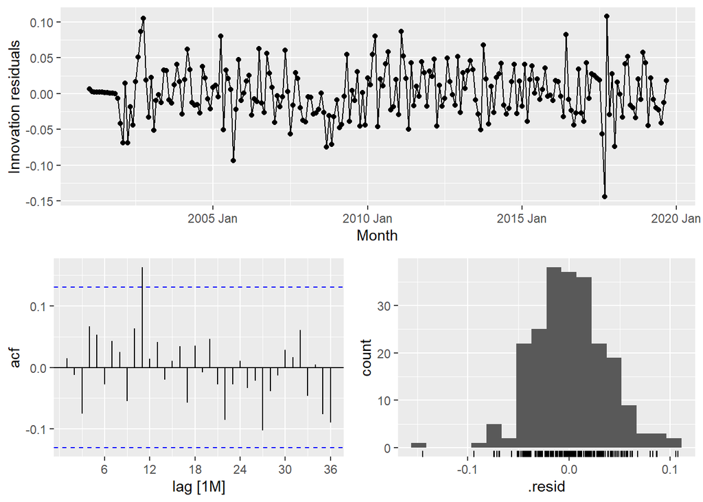

```r
fit %>% select(auto) %>% gg_tsresiduals(lag=36)
```

```r
n_params <- fit %>% select(auto) %>% tidy() %>% nrow()
augment(fit) %>%
  filter(.model == "auto") %>%
  # Lag 24 = 2*m
  features(.innov, ljung_box, lag=24, dof=4)
```

```
# A tibble: 1 × 3
  .model lb_stat lb_pvalue
  <chr>    <dbl>     <dbl>
1 auto      16.6     0.680
```

The high p-value indicates that we fail to reject the null, that is, we the hypothesis that the residuals are in fact white noise.

We now have a **seasonal ARIMA model** that has been **selected based on AICc** and **passes the residuals test**. It is ready for forecasting:

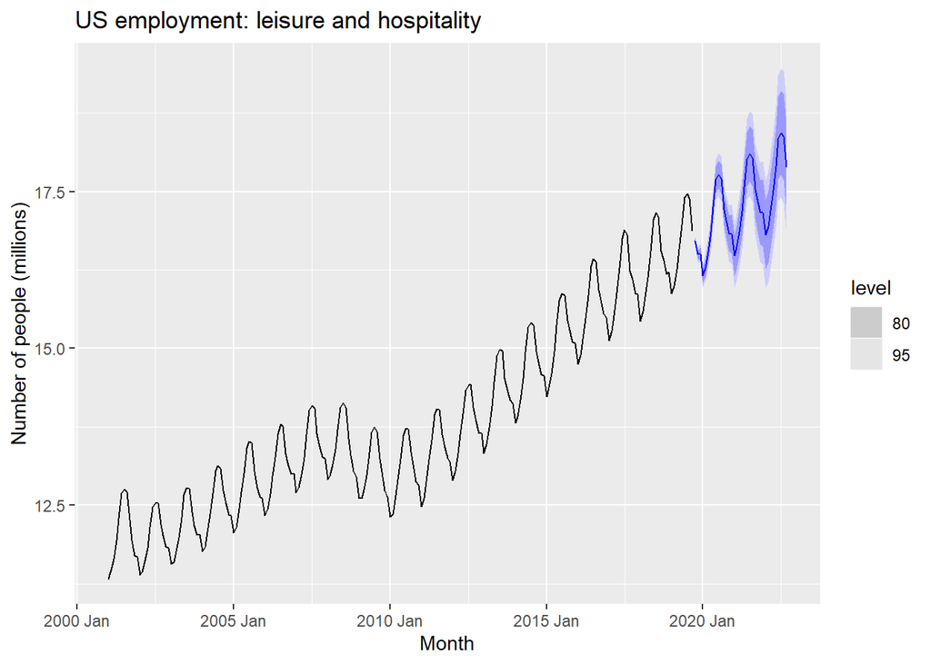

```r
forecast(fit, h=36) %>%
  filter(.model=='auto') %>%
  autoplot(leisure) +
  labs(title = "US employment: leisure and hospitality",
       y="Number of people (millions)")
```

- Seasonal pattern captured well
- Increasing trend extends the recent pattern. The trend is induced by the double differencing.

### Corticosteroid drug sales in australia

H02 drugs under the Anatomical Therapeutic Chemical classification scheme:

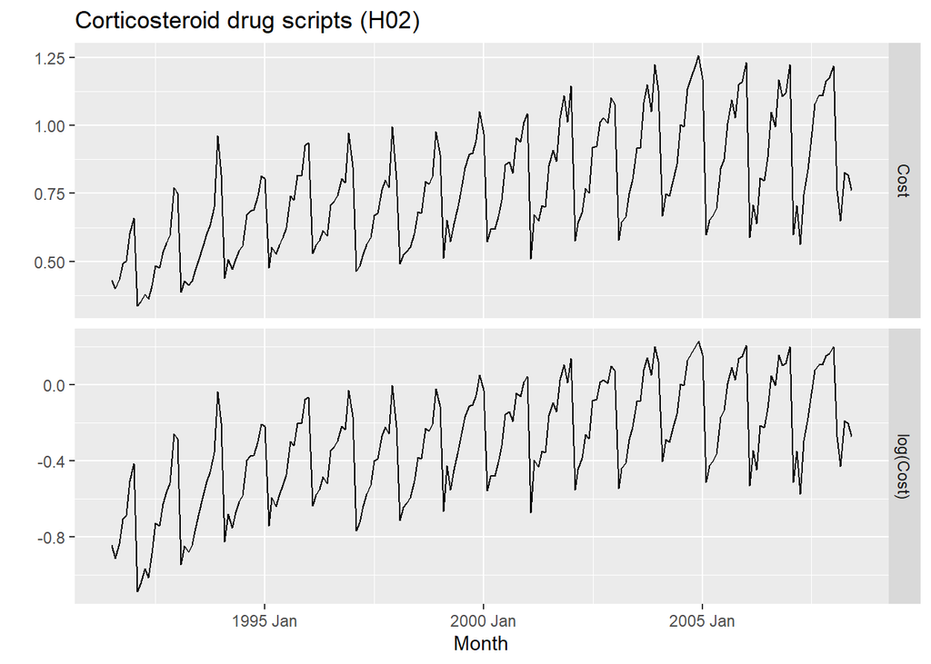

```r
h02 <- PBS %>%
  filter(ATC2 == "H02") %>%
  summarise(Cost = sum(Cost)/1e6)

h02 %>%
  mutate(log(Cost)) %>%
  pivot_longer(-Month) %>%
  ggplot(aes(x = Month, y = value)) +
  geom_line() +
  facet_grid(name ~ ., scales = "free_y") +
  labs(y="", title="Corticosteroid drug scripts (H02)")
```

Have this chart in mind to follow the steps necessary to fit an ARIMA model:

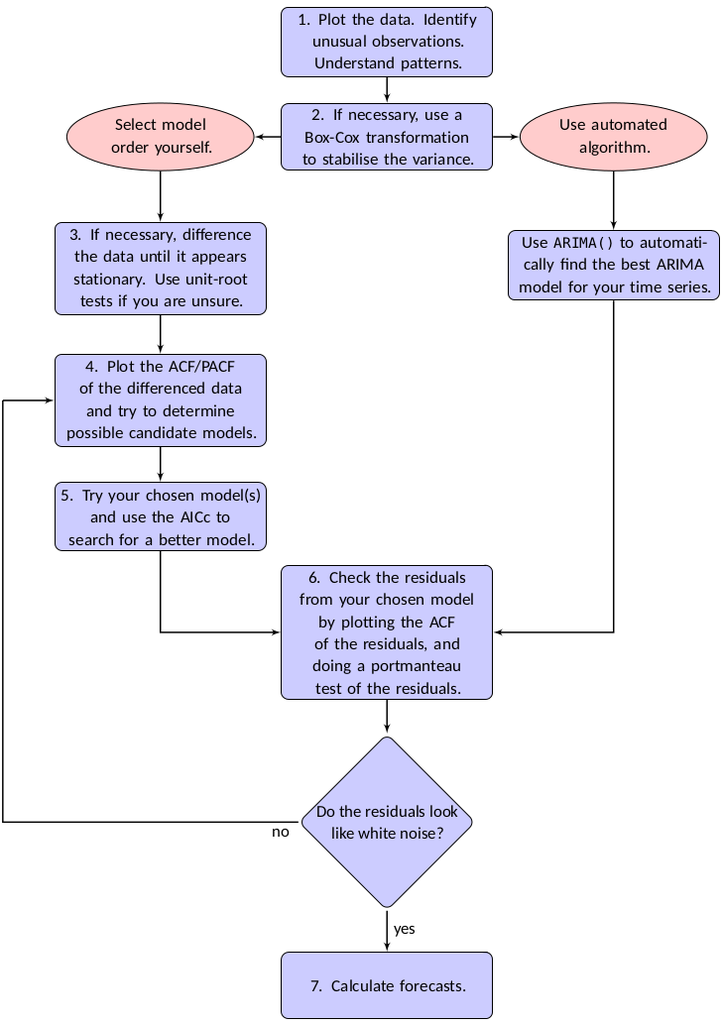

Logarithmic transformation to stabilize the increasing variance with the series.

After this there is strong seasonality and obvious trend non-stationarity.

We will take differences to do away with these two features

```r
h02 <-
  h02 %>%
  mutate(
    sdiff_logcost = difference(log(Cost), 12),
    sdiff_diff_logcost = difference(sdiff_logcost, 1)
  )
```

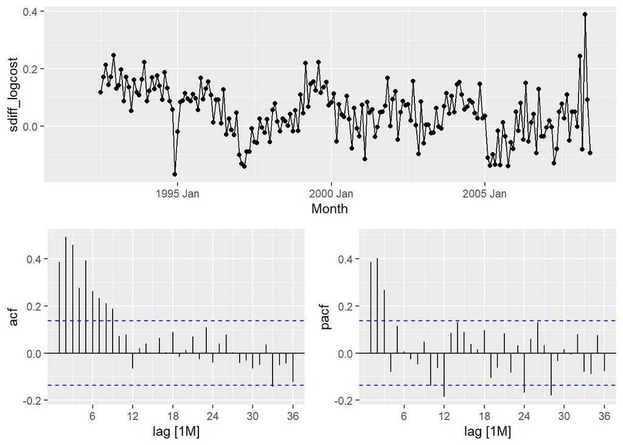

```r
h02 %>% gg_tsdisplay(sdiff_logcost,
                     plot_type='partial', lag_max = 36)
```

Look at the last few observations. They look different from the rest. This migt be because data are sometimes revised when earlier sales are reported late (that is, data might still need to be consolidated).

For the data subject to only one seasonal difference $d=0, D=1$:

- Non-seasonal part:
  - PACF signals AR(3) (cot-off at lag 3)
  - ACF tails-off
- Seasonal part:
  - PACF signals Seasonal AR(2) (cut-off at second seasonal lag)
  - ACF is not indicative of any simple model (no significant seasonal lags)

Therefore here we will propose ARIMA$(3,0,0)(2,1,0)_12$

For the data subject to both ordinary and seasonal differences ($d=1, D=1$):

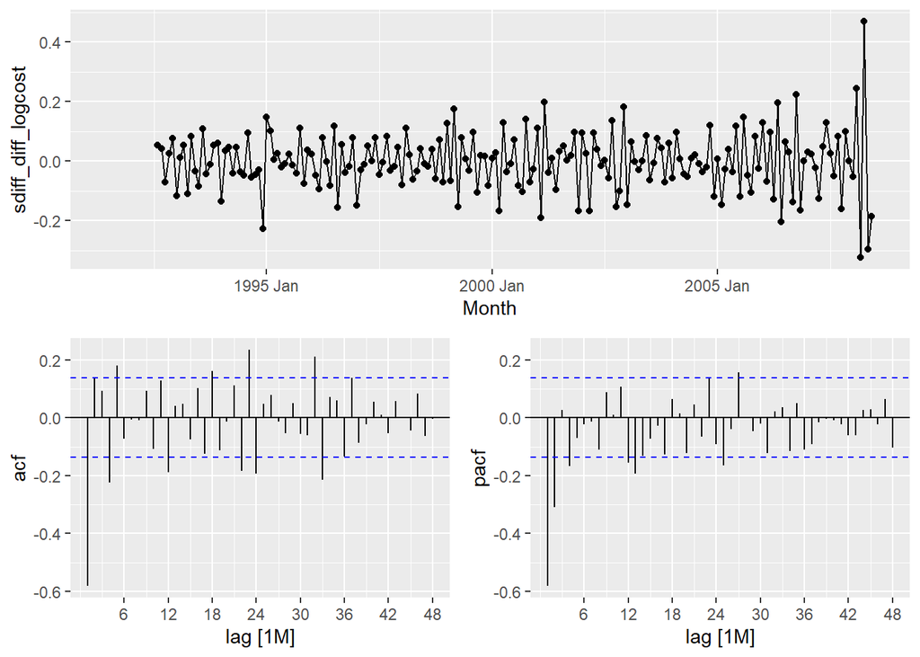

```r
h02 %>% gg_tsdisplay(sdiff_diff_logcost,
                     plot_type='partial', lag_max = 48)
```

- Non-seasonal part:
  - PACF seems to suggest AR(2) or AR(4)
  - ACF is tailing-off
- Seasonal-part
  - ACF seems to suggest seasonal MA(2) (cut-off at second seasonal lag)
  - PACF seems to hint towards a seasonal AR(1) (although the significance of lag 12 is weak).

Therefore, some candidate models could be:

- ARIMA$(2,1,0)(1,1,0)_{12}$
- ARIMA$(2,1,0)(0,1,2)_{12}$

**IMPORTANT NOTE ON ORDERS OF DIFFERENCING**:

We have proposed models with $d=0$ $D=1$ and models with $d=1$ $D=1$.

Note that **these models have different orders of differencing!**, so **a comparison between them in terms of AIC or other information criteria is not possible, because the data to which they have been fitted is different!! (their likelihood is different)**. We can **only compare in terms of AIC models with the same order of differencing**.

We will fit thes models along with:

- An automatically fitted model with all ARIMA orders free.
- An automatically fitted model for which we enforce the constraint $d=0$ and $D=1$.
- An automatically fitted model for which we enforce the constraint $d=1$ and $D=1$.

```r
fit <-
  h02 %>%
    model(
      arima_300210 = ARIMA(log(Cost) ~ pdq(3,0,0) + PDQ(2,1,0)),
      arima_210012 = ARIMA(log(Cost) ~ pdq(2,1,0) + PDQ(0,1,2)),
      arima_210110 = ARIMA(log(Cost) ~ pdq(2,1,0) + PDQ(1,1,0)),
      auto = ARIMA(log(Cost), stepwise = FALSE, approx = FALSE),
      auto_d0_D1 = ARIMA(log(Cost) ~ pdq(d=0) + PDQ(D=1), stepwise = FALSE, approx = FALSE),
      auto_d1_D1 = ARIMA(log(Cost) ~ pdq(d=1) + PDQ(D=1), , stepwise = FALSE, approx = FALSE)
    )
```

Let us create a table to inspect the orders of the automatically fitted models along with those we fully specified (this is for the html output, in RStudio it is best to inspect the variable in the variable explorer)

```r
fit %>% pivot_longer(everything(), names_to = "Model name",
                     values_to = "Orders")
```

```
# A mable: 6 x 2
# Key:     Model name [6]
  `Model name`                             Orders
  <chr>                                   <model>
1 arima_300210 <ARIMA(3,0,0)(2,1,0)[12] w/ drift>
2 arima_210012          <ARIMA(2,1,0)(0,1,2)[12]>
3 arima_210110          <ARIMA(2,1,0)(1,1,0)[12]>
4 auto                  <ARIMA(2,1,3)(0,1,1)[12]>
5 auto_d0_D1   <ARIMA(3,0,1)(0,1,2)[12] w/ drift>
6 auto_d1_D1            <ARIMA(2,1,3)(0,1,1)[12]>
```

#### Comparison in terms of AIC

Remember we can only compare the AIC **between models with the same order of differencing**. This is because **differencing changes the data to which we are fitting the model**.

##### Models with $d=1$ and $D=1$

```r
# Models with d=1 and D=1
fit %>% select(arima_210012, arima_210110, auto, auto_d1_D1) %>% glance() %>% arrange(AIC)
```

```
# A tibble: 4 × 8
  .model        sigma2 log_lik   AIC  AICc   BIC ar_roots   ma_roots
  <chr>          <dbl>   <dbl> <dbl> <dbl> <dbl> <list>     <list>
1 auto         0.00420    251. -488. -487. -465. <cpl [2]>  <cpl [15]>
2 auto_d1_D1   0.00420    251. -488. -487. -465. <cpl [2]>  <cpl [15]>
3 arima_210012 0.00433    247. -484. -483. -467. <cpl [2]>  <cpl [24]>
4 arima_210110 0.00504    234. -461. -461. -448. <cpl [14]> <cpl [0]>
```

The automatically fitted models (`auto` and `auto_d1_D1` have the same spec) have better AIC. Let us compare our best manual guess with the auto-model in terms of residuals:

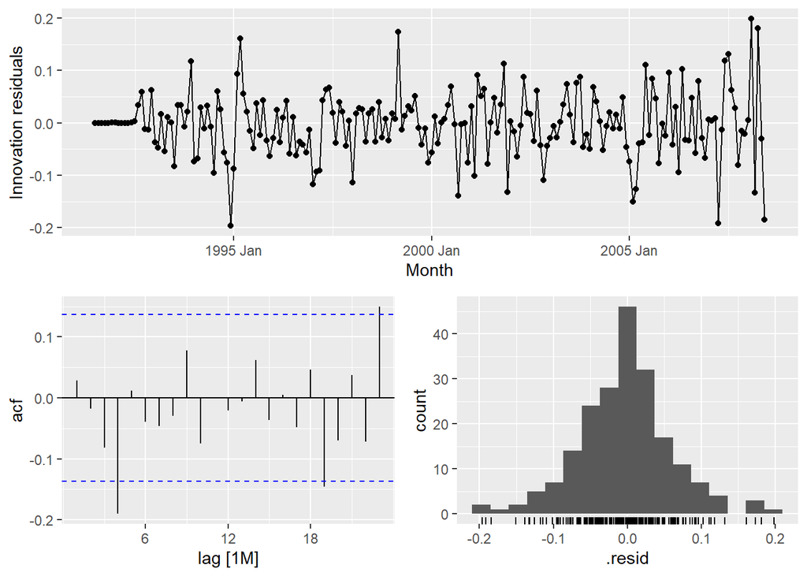

```r
fit %>% select(arima_210012) %>% gg_tsresiduals()
```

```r
n_params <- fit %>% select(arima_210012) %>% tidy() %>% nrow()

augment(fit) %>%
  filter(.model == "arima_210012") %>%
  features(.innov, ljung_box, lag = 24, dof = n_params)
```

```
# A tibble: 1 × 3
  .model       lb_stat lb_pvalue
  <chr>          <dbl>     <dbl>
1 arima_210012    28.0     0.110
```

Satisfies the condition of autocorrelation of the residuals and normality

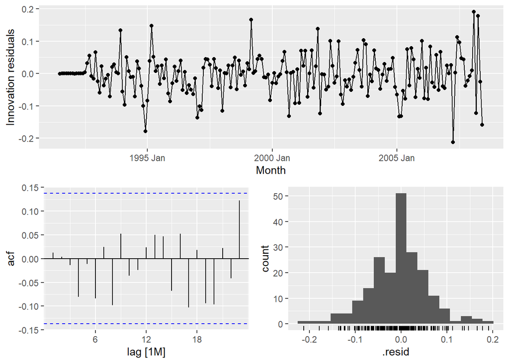

```r
fit %>% select(auto_d1_D1) %>% gg_tsresiduals()
```

```r
n_params <- fit %>% select(auto_d1_D1) %>% tidy() %>% nrow()

augment(fit) %>%
  filter(.model == "auto_d1_D1") %>%
  features(.innov, ljung_box, lag = 24, dof = n_params)
```

```
# A tibble: 1 × 3
  .model     lb_stat lb_pvalue
  <chr>        <dbl>     <dbl>
1 auto_d1_D1    21.5     0.255
```

Satisfies as well the conditions on the residuals.

##### Models with $d=0$ and $D=1$

```r
# Models with d=0 and D=1
fit %>% select(arima_300210, auto_d0_D1) %>% glance() %>% arrange(AIC)
```

```
# A tibble: 2 × 8
  .model        sigma2 log_lik   AIC  AICc   BIC ar_roots   ma_roots
  <chr>          <dbl>   <dbl> <dbl> <dbl> <dbl> <list>     <list>
1 auto_d0_D1   0.00418    253. -490. -489. -464. <cpl [3]>  <cpl [25]>
2 arima_300210 0.00457    246. -478. -477. -455. <cpl [27]> <cpl [0]>
```

We pick the best model in terms of AIC for $d=1$, $D=1$ and $d=0$, $D=1$ and analyze its residuals:

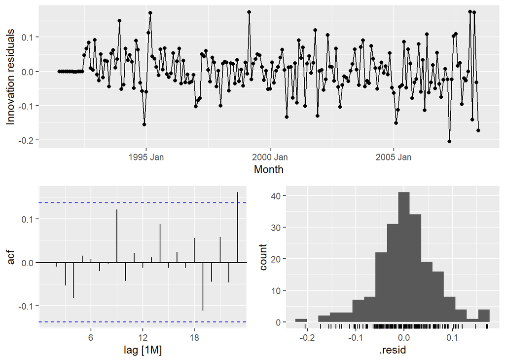

```r
fit %>% select(auto_d0_D1) %>% gg_tsresiduals()
```

```r
n_params <- fit %>% select(auto_d0_D1) %>% tidy() %>% nrow()

augment(fit) %>%
  filter(.model == "auto_d0_D1") %>%
  features(.innov, ljung_box, lag = 24, dof = n_params)
```

```
# A tibble: 1 × 3
  .model     lb_stat lb_pvalue
  <chr>        <dbl>     <dbl>
1 auto_d0_D1    19.4     0.308
```

Lets briefly look at the residuals of the other model:

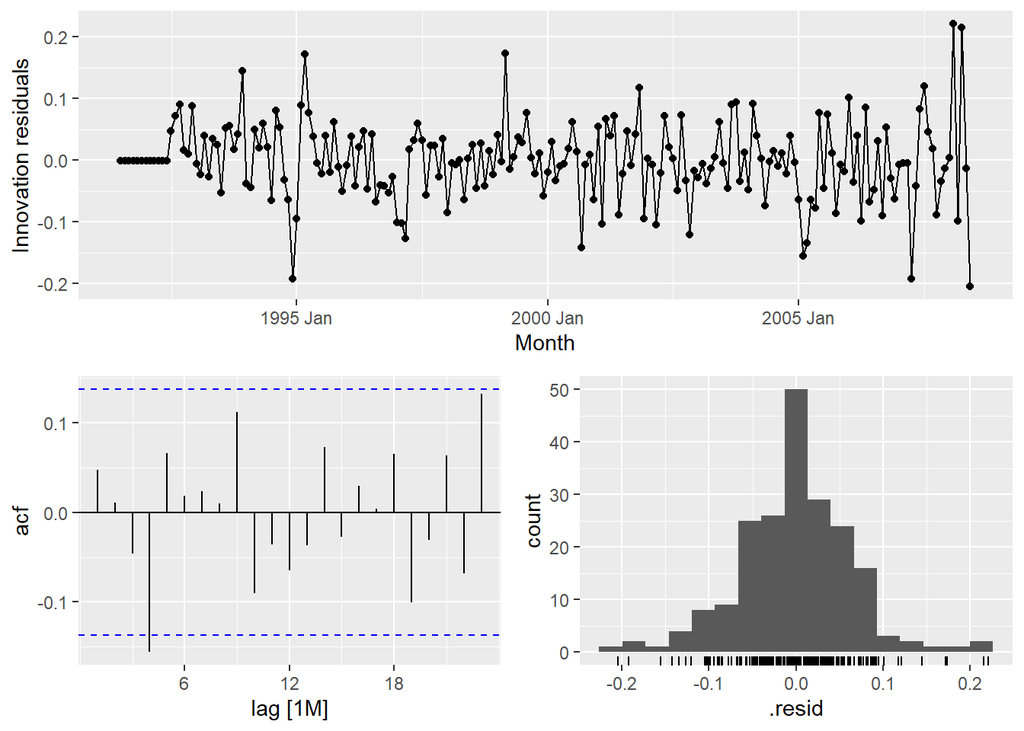

```r
fit %>% select(arima_300210) %>% gg_tsresiduals()
```

```r
n_params <- fit %>% select(arima_300210) %>% tidy() %>% nrow()

augment(fit) %>%
  filter(.model == "arima_300210") %>%
  features(.innov, ljung_box, lag = 24, dof = n_params)
```

```
# A tibble: 1 × 3
  .model       lb_stat lb_pvalue
  <chr>          <dbl>     <dbl>
1 arima_300210    26.3    0.0924
```

Both models seem to satisfy the residuals, but the automatically selected one has much better AIC.

##### NOTE:

In practice, if none of the models passed the residuals test, we would pick the best model we could find, even if it did not pass all of the tests.

#### Comparsion of models in terms of cross-validation

To compare ARIMA models in terms of AIC, it is necessary that they all have the same order of differencing but for cross-validation this is not an issue.

```r
train_smallest <- h02 %>% slice(1:(n()-4*12)) %>% nrow()

h02_cv <- h02 %>% stretch_tsibble(.init=train_smallest, .step = 2)
```

We now need to explicitly state every model, or else R will look for the best model for each training dataset!!. This does not make sense, since we want to compare the same models across all datasets, not fitting one dataset to each model.

```r
fit_cv <-
h02_cv %>%
  model(
    arima_210012 = ARIMA(log(Cost) ~ pdq(2, 1, 0) + PDQ(0, 1, 2)),

    # Automatically fitted now explicitly specified:
    arima_213011 = ARIMA(log(Cost) ~ pdq(2, 1, 3) + PDQ(0, 1, 1)),

    arima_300210 = ARIMA(log(Cost) ~ pdq(3, 0, 0) + PDQ(2, 1, 0)),

    # Automatically fitted now explicitly specified:
    arima_301012 = ARIMA(log(Cost) ~ pdq(3, 0, 1) + PDQ(0, 1, 2))
  )
```

```r
# We want to compute up to two years ahead
fc_cv <-
  fit_cv %>% forecast(h=24)

fc_cv %>% accuracy(h02) %>% arrange(RMSE) %>% select(.model, .type, RMSE)
```

```
# A tibble: 4 × 3
  .model       .type   RMSE
  <chr>        <chr>  <dbl>
1 arima_213011 Test  0.0904
2 arima_210012 Test  0.0975
3 arima_300210 Test  0.106
4 arima_301012 Test  0.112
```

The units of the RMSE are millions of $AUD (Australian dollars).

It appears that the models with both first and second order differences have a lower RMSE. Of these, the automatically selected model (which had a lower AIC than the one we picked up from the ACF and PACF graphs) seems to perform better in terms of RMSE.

This would therefore be a good model to pick among all those that we have fitted.

Finally we would **fit this model to the totality of our data and perform forecasts**:

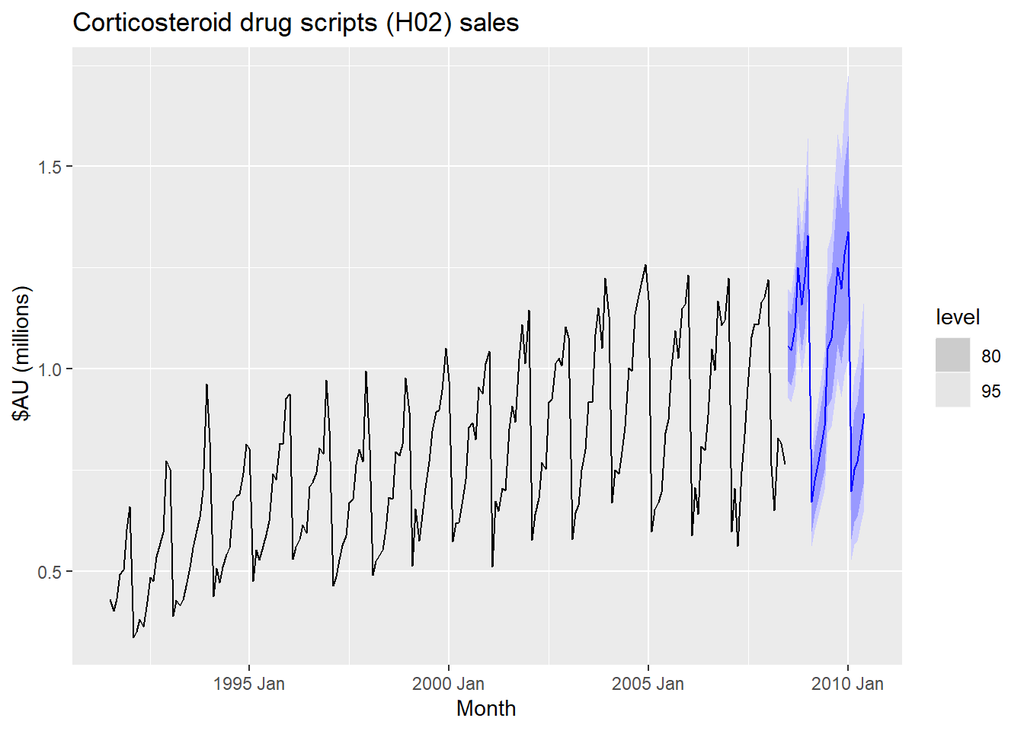

```r
h02 %>%
  model(ARIMA(log(Cost) ~ 0 + pdq(2,1,3) + PDQ(0,1,1))) %>%
  forecast() %>%
  autoplot(h02) +
  labs(y=" $AU (millions)",
       title="Corticosteroid drug scripts (H02) sales")
```